# Multimedia Appendix 2: Supplemental Analyses

Acceptability of Personal Sensing among People with Alcohol Use Disorder

Kendra Wyant, Hannah Moshontz, Stephanie Ward, John Curtin

2021-07-16

Purpose: This file is the supplemental analysis script for *Acceptability of Personal Sensing among People with Alcohol Use Disorder*. It includes all supplemental figures, tables, and statistical analyses.

### Physiology Analysis

We initially monitored participants physiology using an early version of the Empatica E4 wristband monitor. Due to a complicated sensing platform and software bugs we discontinued the wristband after nine participants. Below are the self-reported acceptability ratings (interference, dislike, willingness to continue for one year) for this sensing method from the nine participants who used it (Figure S1 from the manuscript).

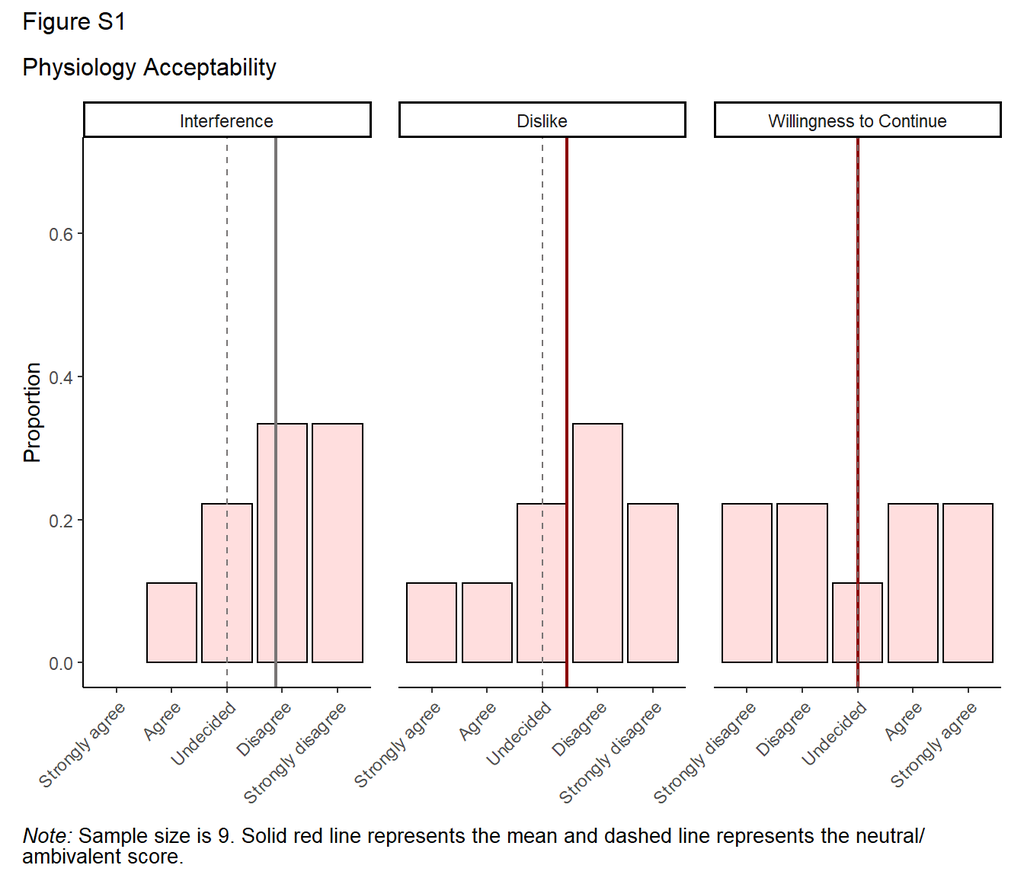

### Time Analysis

Create dataframe of only subids with three time points (N = 133).

The figure below is Figure S2 from the manuscript. We see average acceptability ratings for each personal sensing data stream are relatively stable across time.

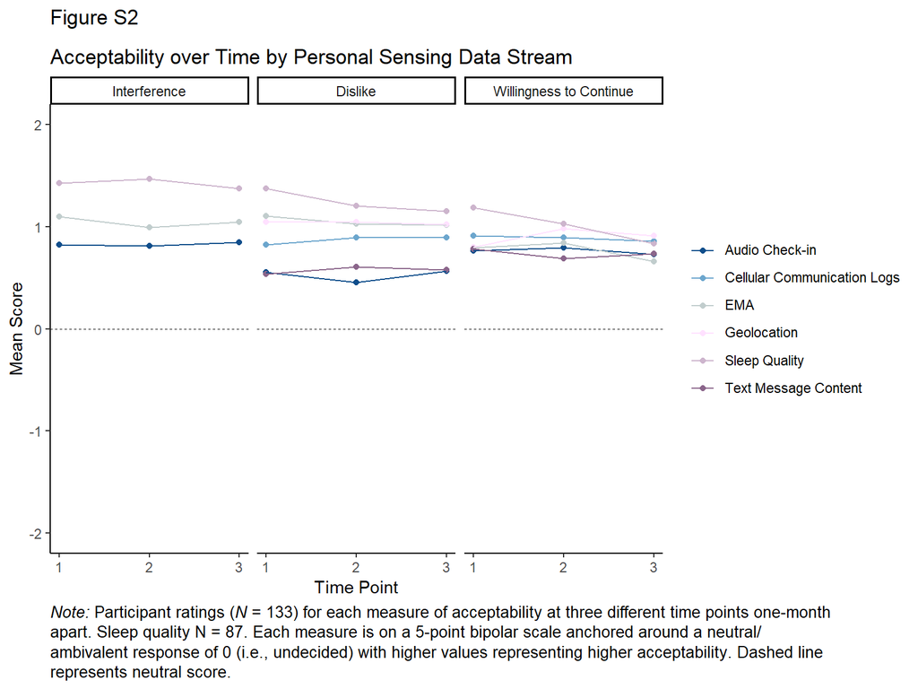

### Analysis on willingness to use EMA one time daily

Participants reported on their willingness to continue an EMA method that was one time daily for one year. This method was hypothetical in that although they were asked about a one time daily EMA they were expected to do four daily EMAs. Below is the distribution of responses for this question (Figure S3 from the manuscript).

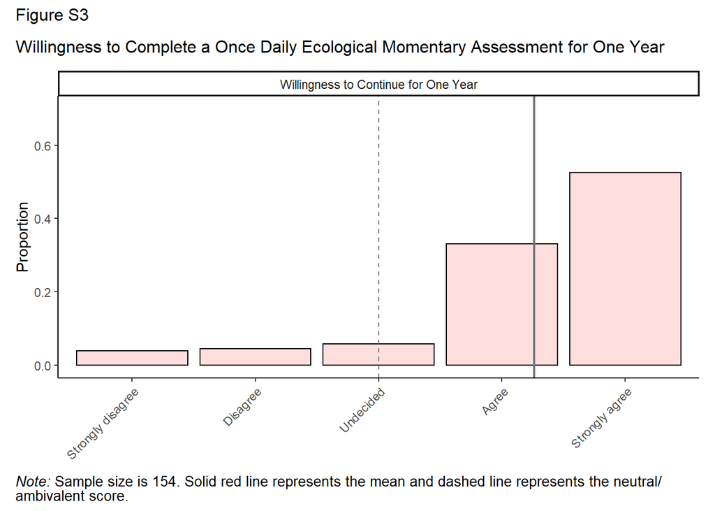

A one sample t-test revealed that the mean willingness score (depicted as the solid red line in Figure S3) was significantly more acceptable than 0 (gray dashed line indicating undecided), t(153) = 15.21, p < .001.

Additionally, we ran a paired samples t-test to compare participants’ willingess to use a one time daily EMA for 1 year compared to a four time daily EMA. We found that Participants were significantly more likely to be willing to complete EMA’s one time daily (M = 1.26, SD = 1.03) compared to four times daily (M = 0.64, SD = 1.22) for one year to help their recovery, t(153) = -8.32, p < .001.

### Group differences between continued and discontinued participants

We ran a series of t-tests to compare demographic information and information relevant to participants’ alcohol use and DSM-5 AUD symptoms in participants who continued vs. discontinued. Continued participants included all participants who were used in the study analyses (i.e., completed through first month followup; N = 154). Discontinued participants consisted of eligible participants who did not enroll or discontinued prior to the first month follow-up (N = 36).

Table S1 Pairwise T-tests to Compare Group Differences between Continued (N = 154) and Discontinued (N = 36) Participants

|  | t | df | p |
| --- | --- | --- | --- |
| age | 1.06 | 48.79 | 0.30 |
| avg_age_aud_milestones | 0.94 | 56.38 | 0.35 |
| dsm5_total | -0.96 | 57.66 | 0.34 |
| education | 1.70 | 46.30 | 0.10 |
| employed | 0.35 | 51.60 | 0.73 |
| Hispanic | -0.06 | 51.07 | 0.95 |
| income | 0.93 | 52.83 | 0.36 |
| male | -1.21 | 53.17 | 0.23 |
| married | 0.67 | 56.12 | 0.51 |
| num_other_drugs | 0.59 | 55.14 | 0.56 |
| num_quit_attempts | -0.75 | 84.11 | 0.46 |
| num_types_tx | 0.52 | 53.36 | 0.61 |
| white | -0.31 | 54.86 | 0.75 |

### Uncorrected pairwise comparisons among personal sensing data streams

Table S2 Uncorrected Pairwise Comparison P Values for Pairs of Personal Sensing Data Streams across the Three Measures of Self Reported Acceptability

| Measure | Audio Check-in | EMA | Sleep Quality | Geolocation | Cellular Communication Logs |
| --- | --- | --- | --- | --- | --- |
| Interference |  |  |  |  |  |
| EMA | .25 |  |  |  |  |
| Sleep Quality | < .001*** | < .001*** |  |  |  |
| Dislike |  |  |  |  |  |
| EMA | < .001*** |  |  |  |  |
| Sleep Quality | < .001*** | .30 |  |  |  |
| Geolocation | < .001*** | .56 | .59 |  |  |
| Cellular Communication Logs | .001*** | .63 | .15 | .29 |  |
| Text Message Content | .56 | .002** | < .001*** | < .001*** | .01** |
| Willingness to Continue |  |  |  |  |  |
| EMA | .47 |  |  |  |  |
| Sleep Quality | .46 | .18 |  |  |  |
| Geolocation | .14 | .03* | .60 |  |  |
| Cellular Communication Logs | .42 | .13 | .97 | .50 |  |
| Text Message Content | .96 | .44 | .49 | .15 | .44 |

Note:  
Sample size for all personal sensing measures is 154 except for the sleep quality which had a sample size of 87. * *p* < .05, ** *p* < .01, *** *p* < .001